# Mapas com ggplot2

## Carregar pacotes

```r
library(sf)
library(geobr)
library(ggplot2)
library(dplyr)
# remotes::install_github("abjur/abjData")
library(abjData)
```

O pacote {sf} (Simple Features for R) (Pebesma 2020, 2018) possibilita trabalhar com bases de dados espaciais.

Para utilizar esses dados, temos duas abordagens: - Bases que não são georreferenciadas - Bases que são georreferenciadas

## Trabalhando com bases não georreferenciadas

Identificar a unidade de análise, e com os joins, unir com uma base georreferenciada.

O pacote **geobr** (Pereira and Goncalves 2020) é um pacote que disponibiliza funções para realizar o download de diversas bases de dados espaciais oficiais do Brasil. Você pode saber mais no repositório do pacote no GitHub: https://ipeagit.github.io/geobr/

## Datasets do Brasil

Quais funções para acessar cada dataset: `geobr::list_geobr()`

```r
knitr::kable(geobr::list_geobr())
```

| function | geography | years | source |
| --- | --- | --- | --- |
| `read_country` | Country | 1872, 1900, 1911, 1920, 1933, 1940, 1950, 1960, 1970, 1980, 1991, 2000, 2001, 2010, 2013, 2014, 2015, 2016, 2017, 2018, 2019, 2020 | IBGE |
| `read_region` | Region | 2000, 2001, 2010, 2013, 2014, 2015, 2016, 2017, 2018, 2019, 2020 | IBGE |
| `read_state` | States | 1872, 1900, 1911, 1920, 1933, 1940, 1950, 1960, 1970, 1980, 1991, 2000, 2001, 2010, 2013, 2014, 2015, 2016, 2017, 2018, 2019, 2020 | IBGE |
| `read_meso_region` | Meso region | 2000, 2001, 2010, 2013, 2014, 2015, 2016, 2017, 2018, 2019, 2020 | IBGE |
| `read_micro_region` | Micro region | 2000, 2001, 2010, 2013, 2014, 2015, 2016, 2017, 2018, 2019, 2020 | IBGE |
| `read_intermediate_region` | Intermediate region | 2017, 2019, 2020 | IBGE |
| `read_immediate_region` | Immediate region | 2017, 2019, 2020 | IBGE |
| `read_municipality` | Municipality | 1872, 1900, 1911, 1920, 1933, 1940, 1950, 1960, 1970, 1980, 1991, 2000, 2001, 2005, 2007, 2010, 2013, 2014, 2015, 2016, 2017, 2018, 2019, 2020 | IBGE |
| `read_municipal_seat` | Municipality seats (sedes municipais) | 1872, 1900, 1911, 1920, 1933, 1940, 1950, 1960, 1970, 1980, 1991, 2010 | IBGE |
| `read_weighting_area` | Census weighting area (área de ponderação) | 2010 | IBGE |
| `read_census_tract` | Census tract (setor censitário) | 2000, 2010, 2017, 2019, 2020 | IBGE |
| `read_statistical_grid` | Statistical Grid of 200 x 200 meters | 2010 | IBGE |
| `read_metro_area` | Metropolitan areas | 1970, 2001, 2002, 2003, 2005, 2010, 2013, 2014, 2015, 2016, 2017, 2018 | IBGE |
| `read_urban_area` | Urban footprints | 2005, 2015 | IBGE |
| `read_amazon` | Brazil’s Legal Amazon | 2012 | MMA |
| `read_biomes` | Biomes | 2004, 2019 | IBGE |
| `read_conservation_units` | Environmental Conservation Units | 201909 | MMA |
| `read_disaster_risk_area` | Disaster risk areas | 2010 | CEMADEN and IBGE |
| `read_indigenous_land` | Indigenous lands | 201907, 202103 | FUNAI |
| `read_semiarid` | Semi Arid region | 2005, 2017 | IBGE |
| `read_health_facilities` | Health facilities | 2015 | CNES, DataSUS |
| `read_health_region` | Health regions and macro regions | 1991, 1994, 1997, 2001, 2005, 2013 | DataSUS |
| `read_neighborhood` | Neighborhood limits | 2010 | IBGE |
| `read_schools` | Schools | 2020 | INEP |
| `read_comparable_areas` | Historically comparable municipalities, aka Areas minimas comparaveis (AMCs) | 1872,1900,1911,1920,1933,1940,1950,1960,1970,1980,1991,2000,2010 | IBGE |
| `read_urban_concentrations` | Urban concentration areas (concentrações urbanas) | 2015 | IBGE |
| `read_pop_arrangements` | Population arrangements (arranjos populacioanis) | 2015 | IBGE |

Exemplos:

```r
# geobr::read_country() # importa a delimitação do Brasil

# geobr::read_state() # importa a delimitação dos estados do Brasil

# geobr::read_state("DF") # importa a delimitação de um Estado específico, usando a sigla

# geobr::read_municipality() # importa a delimitação de todos os municípios do Brasil. É uma base mais pesada!

# geobr::read_municipality(code_muni = 3550308) # importa a delimitação de um município específico, usando o código do IBGE do município.
```

## Exemplo 1: Trabalhando com os estados brasileiros

### Importar as bases

Não usar View()!

- Delimitação dos Estados:
1. Todos os estados do Brasil

```r
estados <- readr::read_rds("../dados/geobr/estados.Rds")

# Como obter essa mesma base?
# estados <- geobr::read_state()
```

2. Apenas um estado: DF

```r
estado_df <- readr::read_rds("../dados/geobr/estado_df.Rds")

# Como obter essa mesma base?
# estado_df <- geobr::read_state("DF")
```

### Explorar os dados

Qual é a classe?

```r
class(estados)
```

```
## [1] "sf"         "data.table" "data.frame"
```

Usamos o pacote ggplot2 para criar os mapas, utilizando o geom_sf()

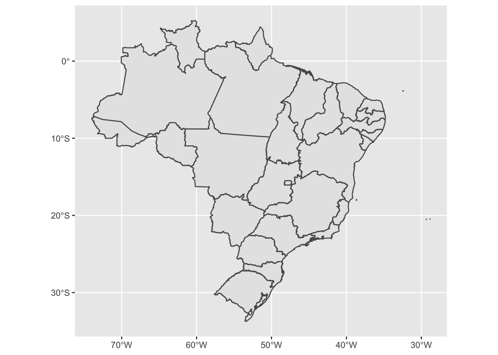

```r
estados %>%
  ggplot() +
  geom_sf()
```

Empilhando as bases usando os geom’s :

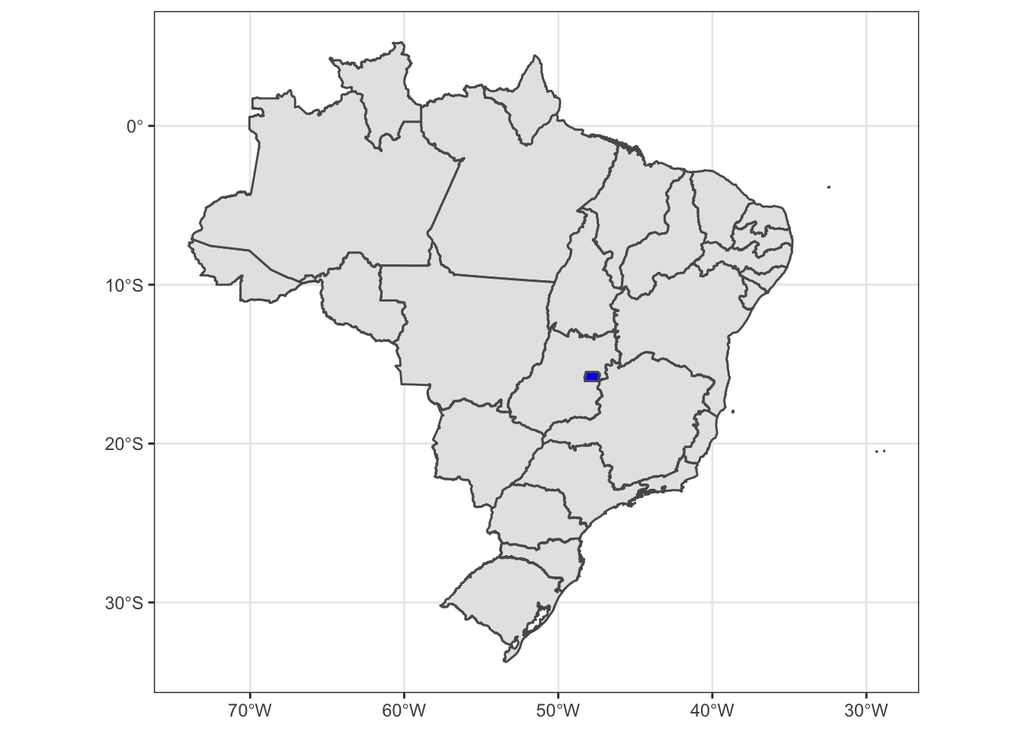

```r
ggplot() +
  geom_sf(data = estados) +
  geom_sf(data = estado_df, fill = "blue") +
  theme_bw()
```

### Usando o dplyr com objetos sf

- glimpse() - observar o que a base contém

```r
glimpse(estados)
```

```
## Rows: 27
## Columns: 6
## $ code_state   <dbl> 11, 12, 13, 14, 15, 16, 17, 21, 22, 23, 24, 25, 26, 27, 2…
## $ abbrev_state <fct> RO, AC, AM, RR, PA, AP, TO, MA, PI, CE, RN, PB, PE, AL, S…
## $ name_state   <fct> Rondônia, Acre, Amazonas, Roraima, Pará, Amapá, Tocantins…
## $ code_region  <dbl> 1, 1, 1, 1, 1, 1, 1, 2, 2, 2, 2, 2, 2, 2, 2, 2, 3, 3, 3, …
## $ name_region  <fct> Norte, Norte, Norte, Norte, Norte, Norte, Norte, Nordeste…
## $ geom         <MULTIPOLYGON [°]> MULTIPOLYGON (((-63.32721 -..., MULTIPOLYGON…
```

- filter() - conseguimos filtrar os objetos

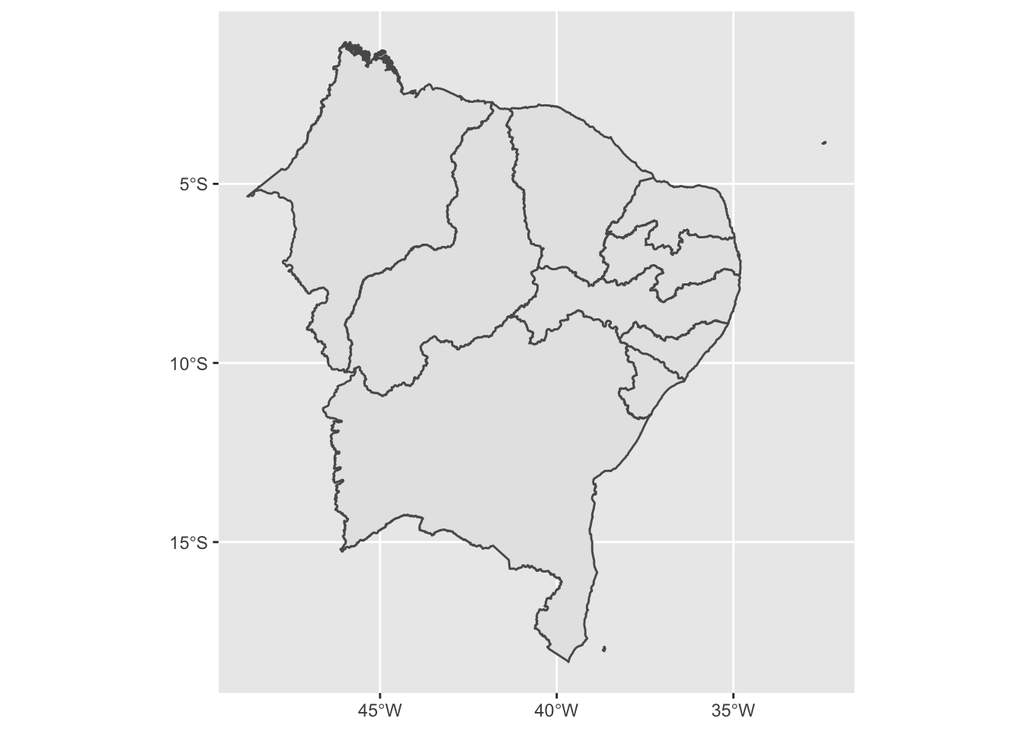

```r
estados %>%
  filter(name_region == "Nordeste") %>%
  ggplot() +
  geom_sf()
```

- join()

```r
class(abjData::pnud_uf)
```

```
## [1] "tbl_df"     "tbl"        "data.frame"
```

```r
pnud_uf_sf <- estados %>%
  left_join(abjData::pnud_uf, by = c("code_state" = "uf"))

class(pnud_uf_sf)
```

```
## [1] "sf"         "data.table" "data.frame"
```

### Mapas temáticos

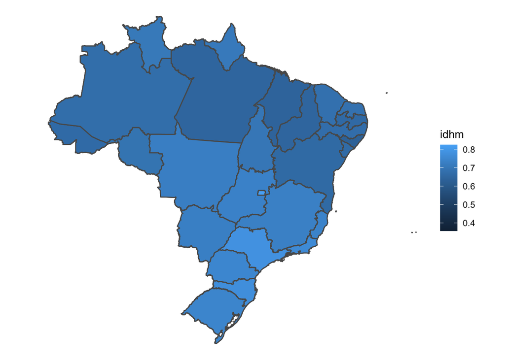

```r
# glimpse(pnud_uf_sf)

pnud_uf_sf  %>%
  ggplot(aes(fill = idhm)) +
  geom_sf() +
  theme_void()
```

## Exemplo 2: Escolas em Brasília, DF

### Carregar os pacotes usados

```r
library(magrittr)
library(dplyr)
library(ggplot2)
```

### Carregar os dados usados

1. Escolas em Brasília

```r
escolas_brasilia <- readr::read_rds("../dados/geobr/escolas_brasilia.Rds")

# Como obter essa mesma base?
# escolas <- geobr::read_schools()
# escolas_brasilia <- escolas %>%
#   filter(abbrev_state == "DF", name_muni == "Brasília")
```

2. Delimitação de Brasília

```r
municipio_brasilia <- readr::read_rds("../dados/geobr/municipio_brasilia.Rds")

# Como obter essa mesma base?
# municipio_brasilia <- geobr::read_municipality(5300108)
```

### Fazer um mapa!

Passo 1: colocar a delimitação do município e também as escolas

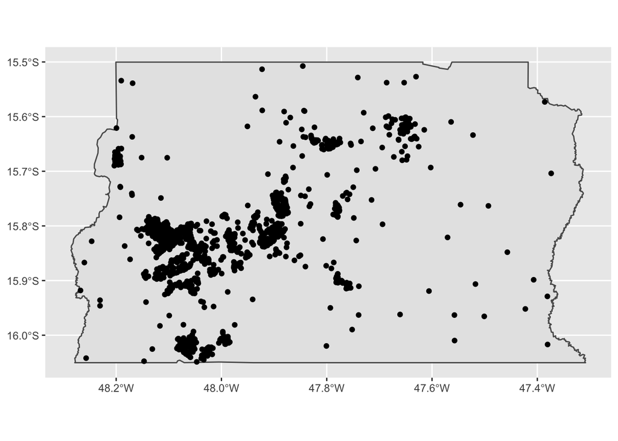

```r
ggplot() +
  geom_sf(data = municipio_brasilia) +
  geom_sf(data = escolas_brasilia)
```

Passo 2: Colorir as escolas por “government_level”

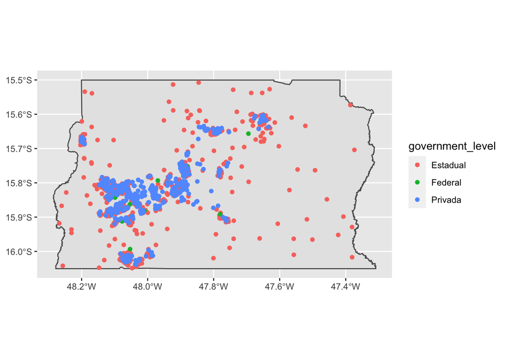

```r
ggplot() +
  geom_sf(data = municipio_brasilia) +
  geom_sf(data = escolas_brasilia, aes(color = government_level))
```

Passo 3: Fazer um facet com “government_level”

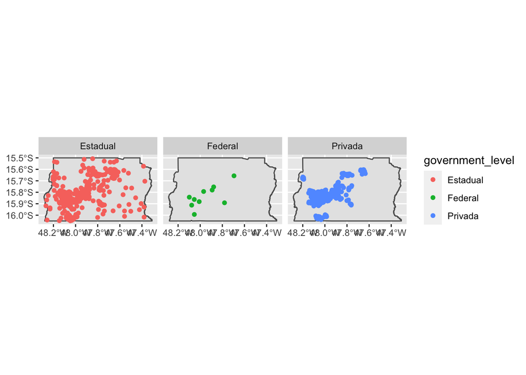

```r
ggplot() +
  geom_sf(data = municipio_brasilia) +
  geom_sf(data = escolas_brasilia, aes(color = government_level)) +
  facet_wrap(~ government_level)
```

Passo 4: Remover a legenda, mudar o tema, adicionar um título e centralizar o título

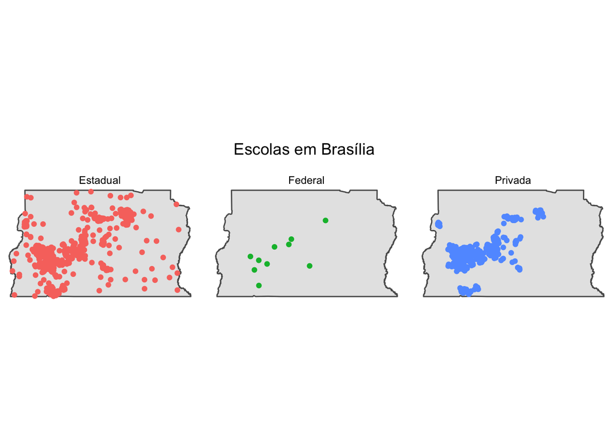

```r
ggplot() +
  geom_sf(data = municipio_brasilia) +
  geom_sf(data = escolas_brasilia, aes(color = government_level), show.legend = FALSE) +
  facet_wrap(~ government_level) +
  theme_void() +
  labs(title = "Escolas em Brasília \n") +
  theme(plot.title = element_text(hjust = 0.5))
```

# Exemplo 3 - Rodovias em DF

### Carregar os pacotes

```r
library(sf)
library(geobr)
```

Como buscar a base? Se quiser baixar, remova os comentários (#) dos códigos abaixo:

```r
# Link que disponibiliza a base
# u_shp <- "https://www.gov.br/infraestrutura/pt-br/centrais-de-conteudo/rodovias-zip"

# Cirar a pasta para baixar o arquivo
# dir.create("../dados/shp_rod")

# Fazer o download do arquivo zip
# httr::GET(u_shp,
#           httr::write_disk("../dados/shp_rod/rodovias.zip"),
#           httr::progress())

# Descompactar o zip
# unzip("../dados/shp_rod/rodovias.zip", exdir = "../dados/shp_rod/")
```

### Importar a base em arquivo .shp (Trabalhando com bases georreferenciadas)

```r
rodovias <-
  st_read(
    "../dados/shp_rod/rodovias.shp",
    quiet = TRUE#,
    #options = "ENCODING=WINDOWS-1252"
  ) %>%
  # limpar o nome das colunas
  janitor::clean_names()
```

- filtrar para DF

```r
rodovias_df <- rodovias %>%
  filter(sg_uf == "DF")
```

### Fazendo um mapa simples

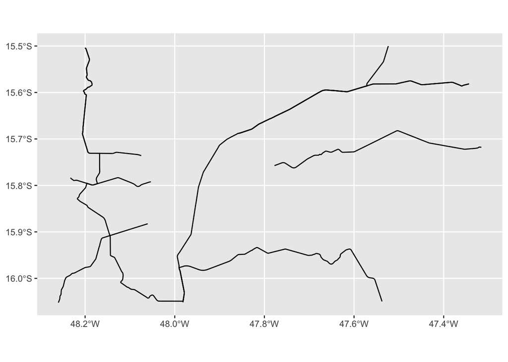

```r
ggplot() +
  geom_sf(data = rodovias_df)
```

## Juntar os 3 exemplos!

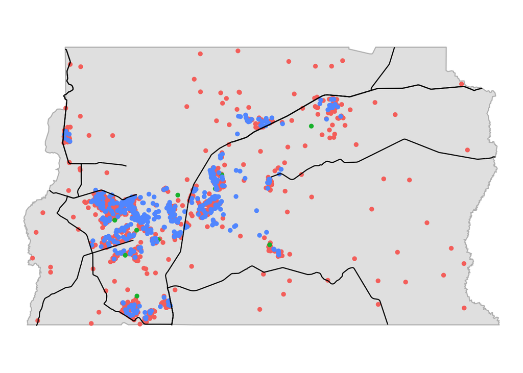

```r
# Inicio do ggplot
ggplot() +
  # limite do estado
  geom_sf(data = estado_df, color = "gray") +
  # escolas
  geom_sf(data = escolas_brasilia, aes(color = government_level), show.legend = FALSE) +
  # rodovias
  geom_sf(data = rodovias_df, color = "black") +
  # adicionar tema
  theme_void()
```